# Unsupervised Learning: Trade&Ahead

### Cluster Profiling

```python
#group dataset by Hierarchical clusters
hc_cluster_profile = df3.groupby("HC_segments").mean()
```

```python
#add counts for number of stocks in each cluster
hc_cluster_profile["count_in_each_segments"] = (
    df3.groupby("HC_segments")["Security"].count().values
)
```

```python
#show dataframe with maximum values for each metric highlighted
hc_cluster_profile.style.highlight_max(color="lightgreen", axis=0)
```

| HC_segments | Current Price | Price Change | Volatility | ROE | Cash Ratio | Net Cash Flow | Net Income | Earnings Per Share | Estimated Shares Outstanding | P/E Ratio | P/B Ratio | count_in_each_segments |
| --- | --- | --- | --- | --- | --- | --- | --- | --- | --- | --- | --- | --- |
| 0 | 213.518640 | 15.252913 | 1.779861 | 22.333333 | 258.740741 | 1504052814.814815 | 1716529851.851852 | 5.177407 | 689838338.441482 | 78.441603 | 13.022590 | 27 |
| 1 | 84.355716 | 3.854981 | 1.827670 | 633.571429 | 33.571429 | -568400000.000000 | -4968157142.857142 | -10.841429 | 398169036.442857 | 42.284541 | -11.589502 | 7 |
| 2 | 46.672222 | 5.166566 | 1.079367 | 25.000000 | 58.333333 | -3040666666.666667 | 14848444444.444445 | 3.435556 | 4564959946.222222 | 15.596051 | -6.354193 | 9 |
| 3 | 72.421687 | 4.563230 | 1.403434 | 25.218182 | 55.014545 | 72801872.727273 | 1572467469.090909 | 3.728564 | 445003946.148764 | 24.188244 | -2.966949 | 275 |
| 4 | 36.440455 | -16.073408 | 2.832884 | 57.500000 | 42.409091 | -472834090.909091 | -3161045227.272727 | -8.005000 | 514367806.201818 | 85.555682 | 0.836839 | 22 |

```python
## Complete the code to print the companies in each cluster
for cl in df3["HC_segments"].unique():
    print("In cluster {}, the following companies are present:".format(cl))
    print(df3[df3["HC_segments"] == cl]["Security"].unique())
    print()
```

```
In cluster 3, the following companies are present:
['American Airlines Group' 'AbbVie' 'Abbott Laboratories'
 'Analog Devices, Inc.' 'Archer-Daniels-Midland Co' 'Ameren Corp'
 'American Electric Power' 'AFLAC Inc'
 'American International Group, Inc.' 'Apartment Investment & Mgmt'
 'Assurant Inc' 'Arthur J. Gallagher & Co.' 'Akamai Technologies Inc'
 'Albemarle Corp' 'Alaska Air Group Inc' 'Allstate Corp' 'AMETEK Inc'
 'Affiliated Managers Group Inc' 'Ameriprise Financial'
 'American Tower Corp A' 'AutoNation Inc' 'Anthem Inc.' 'Aon plc'
 'Amphenol Corp' 'Arconic Inc' 'Activision Blizzard'
 'AvalonBay Communities, Inc.' 'American Water Works Company Inc'
 'American Express Co' 'Boeing Company' 'Baxter International Inc.'
 'BB&T Corporation' 'Bard (C.R.) Inc.' 'BIOGEN IDEC Inc.'
 'The Bank of New York Mellon Corp.' 'Ball Corp' 'Bristol-Myers Squibb'
 'Boston Scientific' 'BorgWarner' 'Boston Properties' 'Caterpillar Inc.'
 'Chubb Limited' 'CBRE Group' 'Crown Castle International Corp.'
 'Carnival Corp.' 'CF Industries Holdings Inc' 'Citizens Financial Group'
 'Church & Dwight' 'C. H. Robinson Worldwide' 'CIGNA Corp.'
 'Cincinnati Financial' 'Comerica Inc.' 'CME Group Inc.' 'Cummins Inc.'
 'CMS Energy' 'Centene Corporation' 'CenterPoint Energy'
 'Capital One Financial' 'The Cooper Companies' 'CSX Corp.'
 'CenturyLink Inc' 'Cognizant Technology Solutions' 'Citrix Systems'
 'CVS Health' 'Chevron Corp.' 'Dominion Resources' 'Delta Air Lines'
 'Du Pont (E.I.)' 'Deere & Co.' 'Discover Financial Services'
 'Quest Diagnostics' 'Danaher Corp.' 'The Walt Disney Company'
 'Discovery Communications-A' 'Discovery Communications-C'
 'Delphi Automotive' 'Digital Realty Trust' 'Dun & Bradstreet'
 'Dover Corp.' 'Dr Pepper Snapple Group' 'Duke Energy' 'DaVita Inc.'
 'eBay Inc.' 'Ecolab Inc.' 'Consolidated Edison' 'Equifax Inc.'
 "Edison Int'l" 'Eastman Chemical' 'Equity Residential' 'EQT Corporation'
 'Eversource Energy' 'Essex Property Trust, Inc.' 'E*Trade'
 'Eaton Corporation' 'Entergy Corp.' 'Exelon Corp.' "Expeditors Int'l"
 'Expedia Inc.' 'Extra Space Storage' 'Fastenal Co'
 'Fortune Brands Home & Security' 'FirstEnergy Corp'
 'Fidelity National Information Services' 'Fiserv Inc' 'FLIR Systems'
 'Fluor Corp.' 'Flowserve Corporation' 'FMC Corporation'
 'Federal Realty Investment Trust' 'General Dynamics'
 'General Growth Properties Inc.' 'Gilead Sciences' 'Corning Inc.'
 'General Motors' 'Genuine Parts' 'Garmin Ltd.' 'Goodyear Tire & Rubber'
 'Grainger (W.W.) Inc.' 'Halliburton Co.' 'Hasbro Inc.'
```

[output cut: 63 more lines]

```
 'S&P Global, Inc.']

In cluster 4, the following companies are present:
['Anadarko Petroleum Corp' 'Baker Hughes Inc' 'Cabot Oil & Gas'
 'Concho Resources' 'Devon Energy Corp.' 'EOG Resources'
 'Freeport-McMoran Cp & Gld' 'Hess Corporation' 'Kinder Morgan'
 'Marathon Oil Corp.' 'Murphy Oil' 'Noble Energy Inc'
 'Newfield Exploration Co' 'National Oilwell Varco Inc.' 'ONEOK'
 'Occidental Petroleum' 'Range Resources Corp.' 'Spectra Energy Corp.'
 'Southwestern Energy' 'Teradata Corp.' 'Williams Cos.' 'Cimarex Energy']

In cluster 2, the following companies are present:
['Citigroup Inc.' 'Ford Motor' 'JPMorgan Chase & Co.' 'Coca Cola Company'
 'Pfizer Inc.' 'AT&T Inc' 'Verizon Communications' 'Wells Fargo'
 'Exxon Mobil Corp.']
```

```python
#print number of stocks within each sector for all of the clusters
for k in range(0,df3['HC_segments'].nunique()):
    print('The number of stocks within each GICS Sector for Cluster '+str(k)+' are:')
    print(df3[df3['HC_segments']==k]['GICS Sector'].value_counts())
    print("   ")
```

```
The number of stocks within each GICS Sector for Cluster 0 are:
Information Technology         9
Health Care                    8
Consumer Discretionary         5
Financials                     1
Real Estate                    1
Telecommunications Services    1
Consumer Staples               1
Materials                      1
Name: GICS Sector, dtype: int64

The number of stocks within each GICS Sector for Cluster 1 are:
Energy                    2
Consumer Staples          2
Industrials               1
Consumer Discretionary    1
Financials                1
Name: GICS Sector, dtype: int64

The number of stocks within each GICS Sector for Cluster 2 are:
Financials                     3
Telecommunications Services    2
Consumer Discretionary         1
Consumer Staples               1
Health Care                    1
Energy                         1
Name: GICS Sector, dtype: int64

The number of stocks within each GICS Sector for Cluster 3 are:
Industrials                    52
Financials                     44
Consumer Discretionary         33
Health Care                    31
Real Estate                    26
Utilities                      24
Information Technology         23
Materials                      18
Consumer Staples               15
Energy                          7
Telecommunications Services     2
Name: GICS Sector, dtype: int64

The number of stocks within each GICS Sector for Cluster 4 are:
Energy                    20
Materials                  1
Information Technology     1
Name: GICS Sector, dtype: int64
```

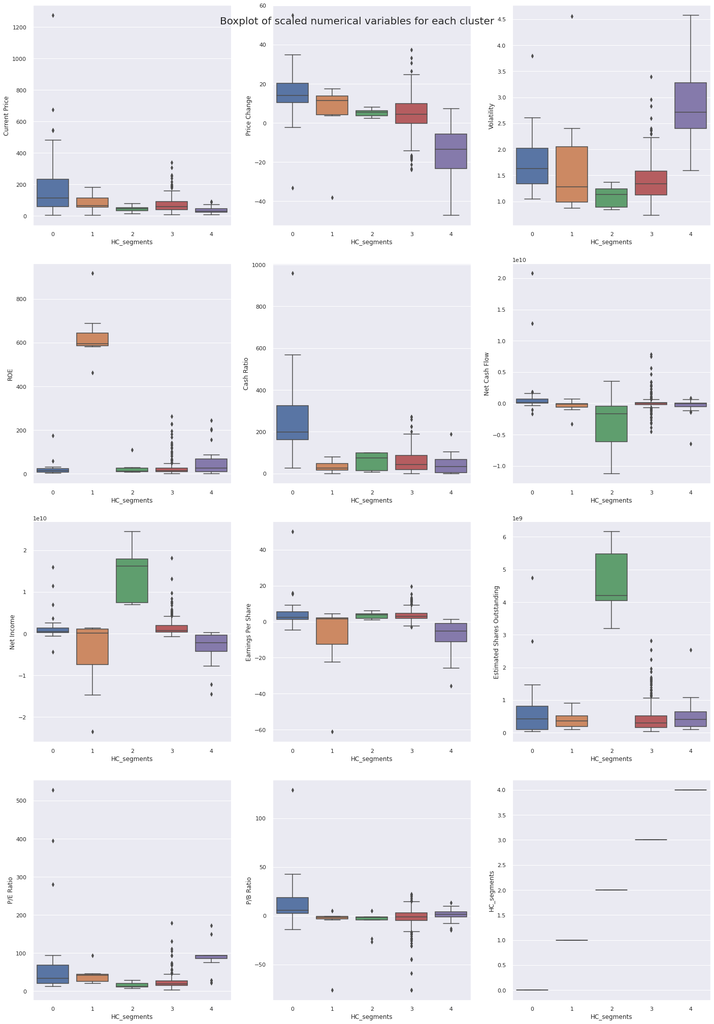

```python
plt.figure(figsize=(20, 35))
plt.suptitle("Boxplot of scaled numerical variables for each cluster", fontsize=20)

# selecting numerical columns
num_cols = df3.select_dtypes(include=np.number).columns.tolist()

for i, variable in enumerate(num_cols):
    plt.subplot(5, 3, i + 1)
    sns.boxplot(data=df3, x="HC_segments", y=variable)

plt.tight_layout(pad=2.0)
```

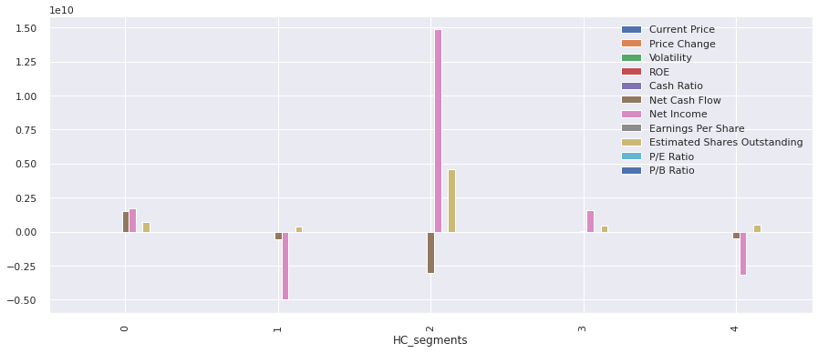

```python
df3.groupby("HC_segments").mean().plot.bar(figsize=(15, 6))
```

### Insights

**Cluster 0:**

- 27 stocks with **Highest** Capital Price of 213 dollars.
- Price change of 15% is highest for these cluster.
- These stock are Less Volatile.
- Highest number of stocks (9) are from **Information Technology** Sector.
- Cash Ratio , Net Cash Flow ,Earning per share and P/B Ratio is **highest** for these stocks.
- Net Income and Outstanding share are moderate.
- P/E ratio is high for this cluster.

**Cluster 2:**

- These cluster has 9 stocks with average Capital Price of 46 dollars.
- Price change is moderate with 5% and the stocks are less volatile.
- *Net Income* and *Shares Outstanding* are **highest** for these cluster.
- Highest number of staocks are from **Financial** sector comprising of 3 companies. -Cash Ratio, Earnings Per share and P/E Ratio is lower for these cluster.

**Cluster 3:**

## K-means vs Hierarchical Clustering

We compare several things, like:

**7.1 Which clustering technique took less time for execution?**

Both the K-means clustering technique and Hierarchical clustering technique took less than a minute to define the clusters.

**7.2 Which clustering technique gave you more distinct clusters, or are they the same?**

- Both technique gave almost similar clusters with single cluster of majority of stocks and remaining slightly similar with very few data points.

**7.3 How many observations are there in the similar clusters of both algorithms?**

- For K Means algorith we got 4 clusters.
- For HC Algorithm we got 5 different clusters.

For both the algorithms the clusters are very well seperated from each other.

## Actionable Insights and Recommendations

- Trade&Ahead should first identify the financial goals, risk tolerance, and investment behaviors of their clients, then recommend a cluster as a potential portfolio of stocks which will fit these needs.
- Trade&Ahead could use these clusters as an starting point for further financial statement analysis, particularly which individual stocks do not fit the "profile" of the cluster
- Assuming selecting individual stocks is a component of a client's investment strategy, Trade&Ahead may then be able to identify stocks which should outperform or likely to fall.
- They should also conduct cluster analysis separately for each of the economic sectors as it will help them to provide better investment recommendations to their clients.